# Welcome to Ruby!

Ruby is a programming language created in 1993 by a really nice guy named Yukihiro Matsumoto.

[figure not shown]

```python
File.open('matz.jpg')
```

That looks like a nice guy, right?

> "For me, the purpose of life is, at least partly, to have joy. Programmers often feel joy when they can concentrate on the creative side of programming, so Ruby is designed to make programmers happy."

## What does Ruby look like?

Let's see some in action.

```python
5.times do
  puts "Hello, Iron Yard students!"
end
```

```
Hello, Iron Yard students!
Hello, Iron Yard students!
Hello, Iron Yard students!
Hello, Iron Yard students!
Hello, Iron Yard students!
```

```
5
```

## Starting Ruby

From the command-line, run `irb`.

```
irb
```

IRb stands for "Interactive Ruby."

## Ruby values

Ruby has a few basic value types we should know in order to use it.

- integers (fixnums)
- decimals (floats)
- strings
- symbols
- booleans
- arrays
- hashes

```python
# Fixnums
1
100
-12

# Floats
7.5
-0.00001
1.0

# Strings
"Hello world!"
'This is a fantastic morning!'

# Symbols
:name
:symbols_make_no_sense

# Booleans
true
false

# Arrays
[1, 2, 3]
["I", "can", :have, ["all", "sorts"], 0, "things in here"]

# Hashes
{:first => "Clinton", :last => "Dreisbach"}
{"key" => "G", "chord_progression" => [1, 4, 5]}
{city: "Durham", state: "NC"}
```

## What is a symbol, anyway?

A symbol is just a name. It stands for something.

Some interesting properties of symbols:

```python
# They are immutable.

"hello".send :upcase!
```

```
"HELLO"
```

```python
:hello.send :upcase!
```

[output not shown]

```python
# There can only be one.

"hello".send :equal?, "hello"
a = "hello"
b = "hello"
b.upcase!
a == b
a
b
```

```
"HELLO"
```

```python
:hello.send :equal?, :hello
```

```
true
```

## What is an array?

It's a sequential collection of things.

```python
letters = ["a", "b", "c", "d"]
```

```
["a", "b", "c", "d"]
```

```python
letters[0]
```

```
"a"
```

```python
names = ["Mae", "Clinton", "Scott", "Chet"]
```

```
["Mae", "Clinton", "Scott", "Chet"]
```

```python
names[0]
```

```
"Mae"
```

```python
IRuby.display IRuby.table(names)
```

| Mae |
| --- |
| Clinton |
| Scott |
| Chet |

```python
# They can contain all sorts of things.
stuff = ["I", "can", :have, ["all", "sorts"], 0, "things in here"]
IRuby.display IRuby.table(stuff)
```

| I |  |
| --- | --- |
| can |  |
| have |  |
| all | sorts |
| 0 |  |
| things in here |  |

## What is a hash?

A hash is an unsorted collection of keys and values.

Instead of numbers pointing to each value, there's a "key" or a name.

```python
person = {:first => "Clinton", :last => "Dreisbach", :hometown => {:city => "Durham", :state => "NC"}}
person[:hometown][:state]
```

```
"NC"
```

```python
person[:last]
```

```
"Dreisbach"
```

```python
person[:middle]
```

[output not shown]

You don't have to use symbols for keys. Other things work, too.

```python
song = {"key" => "G", "chord_progression" => [1, [1, 2, 3], 5]}
song["chord_progression"][1][2]
```

```
3
```

Symbols are used so often for keys that there is a shorthand for doing so. Why do you think symbols are so widely used as keys?

```python
{city: "Durham", state: "NC"}
```

```
{:city=>"Durham", :state=>"NC"}
```

## What did we do up there with `person = ...`?

That's a *variable*. We can assign names to values. Those names are called variables and you can use them in place of the value.

```python
letters = [:a, :b, :c, :d]
```

```
[:a, :b, :c, :d]
```

```python
first_letter = letters[0]
```

```
:a
```

```python
name = {:first => "John", :initial => first_letter}
```

```
{:first=>"John", :initial=>:a}
```

## Take a break!

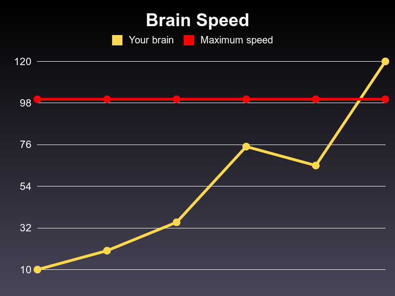

```python
require 'gruff'
g = Gruff::Line.new
g.title = 'Brain Speed'
g.data "Your brain", [10, 20, 35, 75, 65, 120]
g.data "Maximum speed", [100, 100, 100, 100, 100, 100], "red"
g
```